# Classification d’aliments à partir de leurs éléments nutritifs

Jean-Simon Bouchard

2022-08-22

## Processus analytique et objectifs

L’algorithme d’apprentissage machine par arbre de décision CART sera utilisé afin de classifier différents aliments.

La source de données, une base de données relationnelle regroupant 12 fichiers CSV, provient du [Fichier canadien sur les éléments nutritifs (FCÉN), 2015](https://www.canada.ca/fr/sante-canada/services/aliments-nutrition/saine-alimentation/donnees-nutritionnelles/fichier-canadien-elements-nutritifs-fcen-2015.html), tel que consulté le 21 août 2022.

Plus précisément, les éléments suivants seront à l’étude :

- Préparation du jeu de données
- Entraînement du modèle
- Prédictions à partir du modèle et d’un échantillon test
- Validation du modèle

## Exploration des données

Les 4 fichiers source sont d’abord importés avec la fonction read.csv().

```r
library(dplyr)
library(tidyr)
library(xgboost)


setwd("C:\\Users\\jsbou\\Documents\\Dev\\R\\Breakfast\\Dataset\\")

## Importer tous les fichiers sources au format CSV vers un dataframe
food_group <- read.csv(file="FOOD GROUP.csv", stringsAsFactors = TRUE)
food_name <- read.csv(file="FOOD NAME.csv", stringsAsFactors = TRUE)
nutrient_amount <- read.csv(file="NUTRIENT AMOUNT.csv", stringsAsFactors = TRUE)
nutrient_name <- read.csv(file="NUTRIENT NAME.csv", stringsAsFactors = TRUE)
```

Ensuite, les types de données sont modifiés.

```r
str(food_group)
```

```
## 'data.frame':    23 obs. of  4 variables:
##  $ FoodGroupID   : int  1 2 3 4 5 6 7 8 9 10 ...
##  $ FoodGroupCode : int  1 2 3 4 5 6 7 8 9 10 ...
##  $ FoodGroupName : Factor w/ 23 levels "Babyfoods","Baked Products",..: 7 21 1 9 17 20 18 5 11 16 ...
##  $ FoodGroupNameF: Factor w/ 23 levels "Ageau, veau et gibier",..: 21 7 2 12 20 15 22 5 8 19 ...
```

```r
str(food_name)
```

```
## 'data.frame':    5690 obs. of  10 variables:
##  $ FoodID               : int  2 4 5 6 7 8 9 10 13 14 ...
##  $ FoodCode             : int  2 4 5 6 7 8 9 10 13 14 ...
##  $ FoodGroupID          : int  22 22 22 18 22 22 22 22 2 2 ...
##  $ FoodSourceID         : int  20 20 0 20 36 30 30 30 20 0 ...
##  $ FoodDescription      : Factor w/ 5689 levels "Abiyuch, raw",..: 1195 1514 1493 1634 389 2557 3256 4555 5556 5557 ...
##  $ FoodDescriptionF     : Factor w/ 5685 levels "Abiyuch, cru",..: 5052 1529 3345 3284 701 4734 3645 2021 5550 5551 ...
##  $ FoodDateOfEntry      : Factor w/ 337 levels "1981-01-01","1983-01-01",..: 1 1 1 1 1 1 1 1 1 1 ...
##  $ FoodDateOfPublication: Factor w/ 21 levels "","1997-04-01",..: 1 1 1 1 1 1 1 1 1 1 ...
##  $ CountryCode          : int  NA NA 36623 NA NA NA NA NA 2048 2053 ...
##  $ ScientificName       : Factor w/ 468 levels "","Abelmoschus esculentus",..: 1 1 1 1 1 1 1 1 1 1 ...
```

```r
food_name$FoodDateOfEntry <- as.Date(food_name$FoodDateOfEntry)
food_name$FoodDateOfPublication <- as.Date(food_name$FoodDateOfPublication)

str(nutrient_name)
```

```
## 'data.frame':    152 obs. of  8 variables:
##  $ NutrientID      : int  203 204 205 207 208 810 210 211 212 213 ...
##  $ NutrientCode    : int  203 204 205 207 208 209 210 211 212 213 ...
##  $ NutrientSymbol  : Factor w/ 151 levels "10:0","12:0",..: 120 84 73 58 100 129 131 92 89 102 ...
##  $ NutrientUnit    : Factor w/ 7 levels "µg","g","IU",..: 2 2 2 2 4 2 2 2 2 2 ...
##  $ NutrientName    : Factor w/ 152 levels "ALANINE","ALCOHOL",..: 121 28 19 7 26 129 131 95 92 102 ...
##  $ NutrientNameF   : Factor w/ 152 levels "ACIDE ASPARTIQUE",..: 127 112 104 84 92 72 137 105 101 110 ...
##  $ Tagname         : Factor w/ 145 levels "","ALA","ALC",..: 116 78 14 5 21 123 125 91 88 97 ...
##  $ NutrientDecimals: int  2 2 2 2 0 2 2 2 2 2 ...
```

## Préparation des données

Les jeux de données étant liés entre eux, certaines manipulations des données sont nécessaires afin d’obtenir un jeu de données prêt pour être utilisé dans le modèle.

```r
# Regroupement des données sur les aliments et les groupes d'aliments
food_name_labeled <- left_join(food_name, food_group, by = "FoodGroupID") %>%
  select(FoodID, FoodDescriptionF, FoodGroupNameF)

# Regroupement des données sur les nutriments et les quantités de nutriments
nutrient_labeled <- left_join(nutrient_name, nutrient_amount, by = "NutrientID") %>%
  select(FoodID, NutrientNameF, NutrientValue)

# Transposition du dataframe nutrient_labeled afin d'obtenir une colonne par type de nutriment
nutrient_wider <- nutrient_labeled %>%
  pivot_wider(id_cols = FoodID, values_from = NutrientValue, names_from = NutrientNameF)

# Regroupement des données sur les aliments et les nutriments
food_complete <- left_join(food_name_labeled, nutrient_wider, by = "FoodID")

# Création d'une colonne VRAI/FAUX à savoir si le groupe d'aliment correspond à "Céréales à déjeuner". Le modèle tentera de déterminer si la valeur est vraie ou fausse
food_complete$cereales_dejeuner <- ifelse(food_complete$FoodGroupNameF == "Céréales à déjeuner", TRUE, FALSE)

# Retrait des 3 premières colonnes du jeu de données, car elles ne seront pas nécessaires à l'analyse
food_complete <- food_complete %>%
  select(4:ncol(food_complete))


# Ajustement des noms de colonnes afin d'éviter des noms invalides
colnames(food_complete) <- make.names(colnames(food_complete))
```

Le jeu de données est ensuite séparé en deux ensembles, soit un ensemble d’entraînement (80% des lignes) et un ensemble de test (20% des lignes).

```r
# Fonction permettant de séparer le jeu de données en deux ensembles
create_train_test <- function(data, size = 0.8, train = TRUE) {
    n_row = nrow(data)
    total_row = size * n_row
    train_sample <- 1: total_row
    if (train == TRUE) {
        return (data[train_sample, ])
    } else {
        return (data[-train_sample, ])
    }
}

train <- create_train_test(food_complete, train = TRUE)

test <- create_train_test(food_complete, train = FALSE)
```

## Modélisation

Avec le package rpart, un arbre décisionnel est ensuite généré avec l’ensemble d’entraînement, puis des prédictions sont faites avec l’ensemble de test.

Certaines configurations (variable control ci-dessous) sont aussi incluses dans la fonction rpart(). Voici la signification des différentes configurations :

- minsplit : Le nombre minimal d’observations dans un noeud pour qu’une coupure soit appliquée;
- minbucket : Le nombre minimal d’observations dans un noeud final;
- maxdepth : La profondeur maximale des noeuds de l’arbre final.

L’exactitude, ou plutôt le taux de bonnes classifications correspondent à la somme de la diagonale de la matrice de confusion, divisée par la somme des valeurs de la matrice de confusion.

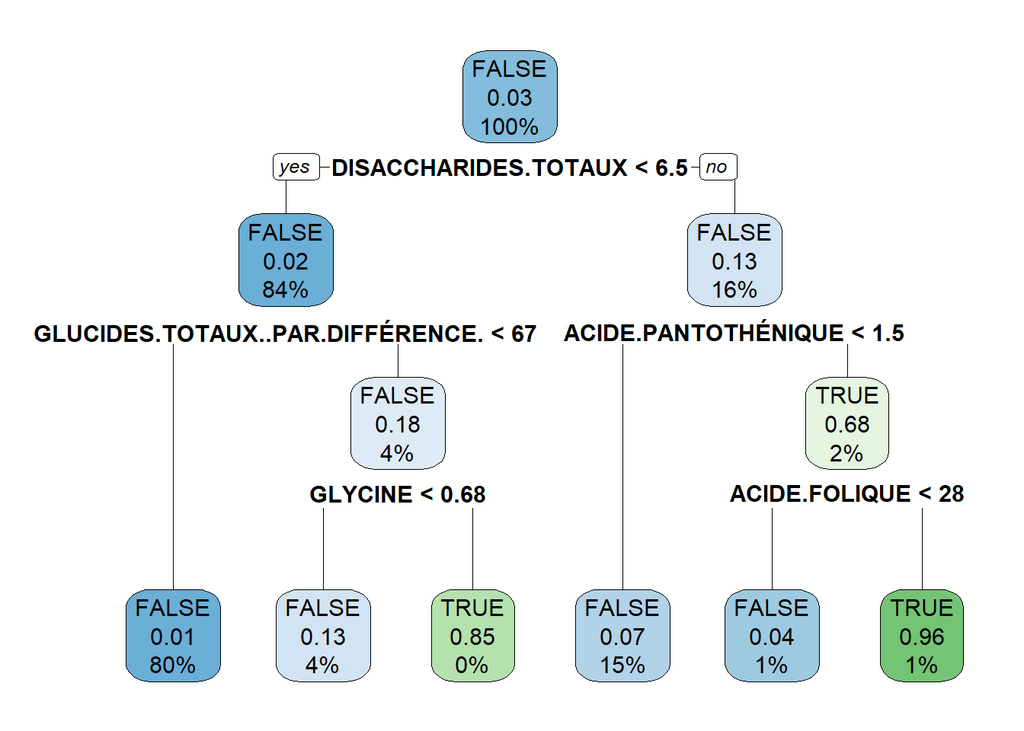

```r
library(rpart)
library(rpart.plot)

control <- rpart.control(minsplit = 4,
    minbucket = round(5 / 3),
    maxdepth = 3,
    cp = 0)

fit <- rpart(cereales_dejeuner~ ., data = train, method = "class", control = control)

rpart.plot(fit)
```

```r
predict <-predict(fit, test, type = "class")

mat_conf <- table(test$cereales_dejeuner, predict)

rownames(mat_conf) <- paste("Actual", rownames(mat_conf), sep = ":")
colnames(mat_conf) <- paste("Pred", colnames(mat_conf), sep = ":")

mat_conf
```

```
##               predict
##                Pred:FALSE Pred:TRUE
##   Actual:FALSE       1082         3
##   Actual:TRUE          35        18
```

```r
exactitude <- sum(diag(mat_conf)) / sum(mat_conf)

print(paste0("Taux de bonnes classifications : ", exactitude))
```

```
## [1] "Taux de bonnes classifications : 0.966608084358524"
```

Avec un taux de bonnes classifications à 0.9666081, le modèle a une précision satisfaisante (97% de bonnes classifications) dans la classification de ce groupe d’aliments à partir des éléments nutritifs de différents aliments.